# Average Real Hourly Earnings for the Education and Training Sector of New Zealand Quarterly GDP for Retail Trade in New Zealand

# Average Real Hourly Earnings for the Education and Training Sector of New Zealand

We have quarterly time series data on average hourly earnings in the education and training sector of New Zealand, from `2012Q1` until `2022Q4`. Nominal earnings are measured in the prices of the day and real earnings are measured in the prices of a fixed base date. The file `earnings.csv` contains average nominal hourly earnings for the education and training sector and the file `cpi.csv` contains the Consumer Price Index (CPI) with base-quarter 2022 Q4. The following code reads these data sets into `R`.

```r
earnings <- read_csv("earnings.csv") %>%
  mutate(Quarter = yearquarter(Quarter)) %>%
  as_tsibble(index = Quarter)
earnings
```

```
## # A tsibble: 44 x 2 [1Q]
##    Quarter Nominal
##      <qtr>   <dbl>
##  1 2012 Q1    30.8
##  2 2012 Q2    30.6
##  3 2012 Q3    30.8
##  4 2012 Q4    30.9
##  5 2013 Q1    30.7
##  6 2013 Q2    31.5
##  7 2013 Q3    31.5
##  8 2013 Q4    31.5
##  9 2014 Q1    31.8
## 10 2014 Q2    31.8
## # … with 34 more rows
```

```r
cpi <- read_csv("cpi.csv") %>%
  mutate(Quarter = yearquarter(Quarter)) %>%
  as_tsibble(index = Quarter)
cpi
```

```
## # A tsibble: 44 x 2 [1Q]
##    Quarter   CPI
##      <qtr> <dbl>
##  1 2012 Q1  789.
##  2 2012 Q2  792.
##  3 2012 Q3  794.
##  4 2012 Q4  793.
##  5 2013 Q1  796.
##  6 2013 Q2  797.
##  7 2013 Q3  805.
##  8 2013 Q4  805.
##  9 2014 Q1  808.
## 10 2014 Q2  810.
## # … with 34 more rows
```

```r
earnings %>%
  slice (1 : 10)%>%
  knitr::kable()
```

| Quarter | Nominal |
| --- | --- |
| 2012 Q1 | 30.84 |
| 2012 Q2 | 30.57 |
| 2012 Q3 | 30.77 |
| 2012 Q4 | 30.87 |
| 2013 Q1 | 30.71 |
| 2013 Q2 | 31.48 |
| 2013 Q3 | 31.48 |
| 2013 Q4 | 31.54 |
| 2014 Q1 | 31.82 |
| 2014 Q2 | 31.77 |

```r
cpi %>%
  slice (1 : 10)%>%
  knitr::kable()
```

| Quarter | CPI |
| --- | --- |
| 2012 Q1 | 789.2178 |
| 2012 Q2 | 791.9299 |
| 2012 Q3 | 793.9640 |
| 2012 Q4 | 792.6079 |
| 2013 Q1 | 795.9980 |
| 2013 Q2 | 797.3541 |
| 2013 Q3 | 804.8123 |
| 2013 Q4 | 805.4904 |
| 2014 Q1 | 808.2024 |
| 2014 Q2 | 810.2365 |

```r
joined_data <- earnings %>%
  left_join(cpi, by = "Quarter")

joined_data
```

```
## # A tsibble: 44 x 3 [1Q]
##    Quarter Nominal   CPI
##      <qtr>   <dbl> <dbl>
##  1 2012 Q1    30.8  789.
##  2 2012 Q2    30.6  792.
##  3 2012 Q3    30.8  794.
##  4 2012 Q4    30.9  793.
##  5 2013 Q1    30.7  796.
##  6 2013 Q2    31.5  797.
##  7 2013 Q3    31.5  805.
##  8 2013 Q4    31.5  805.
##  9 2014 Q1    31.8  808.
## 10 2014 Q2    31.8  810.
## # … with 34 more rows
```

```r
base <- cpi %>%
  pull()  %>%
  last


adjusted_data <- joined_data %>%
  mutate(Real =  Nominal / CPI * base) %>%
  select(-Nominal, -CPI) #I had to remove these 2 because it wouldn't plot `real`
adjusted_data
```

```
## # A tsibble: 44 x 2 [1Q]
##    Quarter  Real
##      <qtr> <dbl>
##  1 2012 Q1  39.1
##  2 2012 Q2  38.6
##  3 2012 Q3  38.8
##  4 2012 Q4  38.9
##  5 2013 Q1  38.6
##  6 2013 Q2  39.5
##  7 2013 Q3  39.1
##  8 2013 Q4  39.2
##  9 2014 Q1  39.4
## 10 2014 Q2  39.2
## # … with 34 more rows
```

```r
fit <- adjusted_data  %>%
  model(SES = ETS(Real ~ error("A") + trend("N") + season("N")),
        HL = ETS(Real ~ error("A") + trend("A") + season("N")),
        HDL = ETS(Real ~ error("A") + trend("Ad") + season("N")))
fit
```

```
## # A mable: 1 x 3
##            SES           HL           HDL
##        <model>      <model>       <model>
## 1 <ETS(A,N,N)> <ETS(A,A,N)> <ETS(A,Ad,N)>
```

```
## Plot variable not specified, automatically selected `.vars = Real`
```

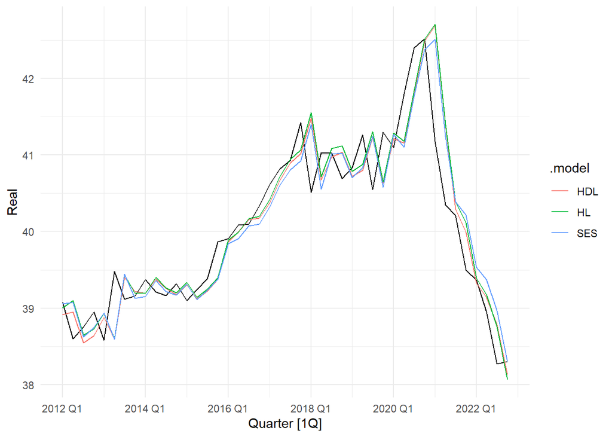

```r
adjusted_data %>%
  autoplot(mapping = aes(x = Quarter,
                         y = Real)) +
  geom_line(data = augment(fit),
            aes(y = .fitted,
                colour = .model)) +
  theme_minimal()
```

```r
report(fit) %>%
  select(.model,AICc)
```

```
## # A tibble: 3 × 2
##   .model  AICc
##   <chr>  <dbl>
## 1 SES     105.
## 2 HL      110.
## 3 HDL     111.
```

The Akaike Information Criterion with Correction (AICc) asseess the goodness of fit of statistical models. Models with lower AICc values are considered better fits to the data. In this example, the Simple Exponential Smoothing (SES) method was found to have the lowest AICc value, indicating that it provides the best fit for the data. The Holts Damped Linear and Holts Linear models were found to have larger AIC values, suggesting that these models are overfitting the data. This could be linked to their complexity, as they may be capturing statistical noise instead of true patterns in the data.

```r
fit %>%
  select(SES) %>%
  report()
```

```
## Series: Real
## Model: ETS(A,N,N)
##   Smoothing parameters:
##     alpha = 0.9569393
##
##   Initial states:
##      l[0]
##  39.05679
##
##   sigma^2:  0.2209
##
##      AIC     AICc      BIC
## 104.0227 104.6227 109.3753
```

`alpha` - The output shows that Alpha is 0.95, which indicates that the Simple Exponential Smoothing model (SES) places more weight on recent observations and less weight on past observations when forecasting the Real variable.

`Extra: sigma^2` The formula for AIC is AIC = -2ln(L) + 2k, where L is the likelihood of the model and k is the no. of parameters and initial states estimated (including the residual variance. Therefore, a larger value of sigma^2 will increase the penalty in the AIC calculation, and favor simpler models with lower residual variance.

# Quarterly GDP for Retail Trade in New Zealand

We have quarterly (chain volume) gross domestic product (QGDP) for the retail trade industry in New Zealand, measured in the prices from 2009/10 in NZD Millions. The data, courtesy of Statistics New Zealand, contains the actual time series as well as the seasonally-adjusted time series, measured from `1987Q2` until `2022Q4`. The following code reads this data set into `R`.

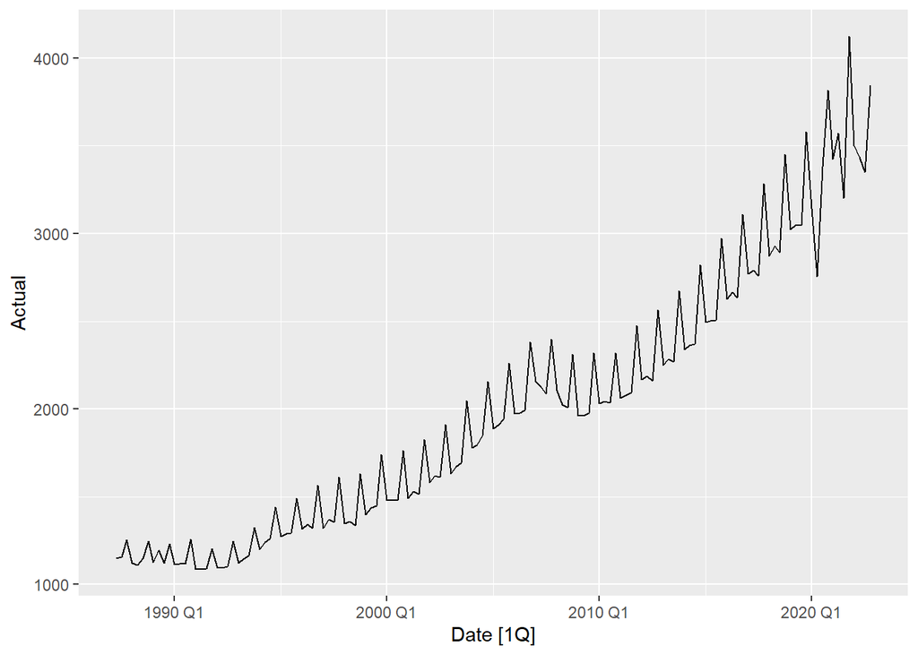

```r
gdp <- read_csv("qgdp_retail.csv") %>%
  mutate(Date = yearquarter(Date)) %>%
  as_tsibble(index = Date)

gdp%>%
  autoplot()
```

```r
dummy1 <- gdp %>%
  mutate(outlier = ifelse(Date %in% yearquarter("2020 Q2"), 1, 0))


gdp_data <- dummy1 %>%
  mutate(unusual = ifelse(Date %in% yearquarter("1989 Q2"), 1, 0))

gdp_data
```

```
## # A tsibble: 143 x 5 [1Q]
##       Date Actual `Seasonally Adjusted` outlier unusual
##      <qtr>  <dbl>                 <dbl>   <dbl>   <dbl>
##  1 1987 Q2   1150                  1180       0       0
##  2 1987 Q3   1157                  1169       0       0
##  3 1987 Q4   1254                  1170       0       0
##  4 1988 Q1   1120                  1160       0       0
##  5 1988 Q2   1108                  1138       0       0
##  6 1988 Q3   1147                  1162       0       0
##  7 1988 Q4   1244                  1158       0       0
##  8 1989 Q1   1125                  1165       0       0
##  9 1989 Q2   1196                  1227       0       1
## 10 1989 Q3   1120                  1140       0       0
## # … with 133 more rows
```

```r
fit <- gdp_data  %>%
  model( m1 = TSLM(log(Actual) ~ trend() + season()),
         m2 = TSLM(log(Actual) ~ trend() + season() + outlier + unusual),
         m3 = TSLM(log(Actual) ~ trend(knots = (yearquarter(c("2008 Q1", "2010 Q1")))) + season() + outlier + unusual))

fit
```

```
## # A mable: 1 x 3
##        m1      m2      m3
##   <model> <model> <model>
## 1  <TSLM>  <TSLM>  <TSLM>
```

```r
glance(fit) %>%
  select(.model, AICc)
```

```
## # A tibble: 3 × 2
##   .model  AICc
##   <chr>  <dbl>
## 1 m1     -820.
## 2 m2     -825.
## 3 m3     -877.
```

```r
# Selecting the best model
fit <- fit %>%
  select(m3)

fit %>%
  report()
```

```
## Series: Actual
## Model: TSLM
## Transformation: log(Actual)
##
## Residuals:
##       Min        1Q    Median        3Q       Max
## -0.093211 -0.021991 -0.004025  0.016968  0.160666
##
## Coefficients:
##                                                                 Estimate
## (Intercept)                                                    6.8811073
## trend(knots = (yearquarter(c("2008 Q1", "2010 Q1"))))trend     0.0086641
## trend(knots = (yearquarter(c("2008 Q1", "2010 Q1"))))trend_84 -0.0116088
## trend(knots = (yearquarter(c("2008 Q1", "2010 Q1"))))trend_92  0.0146763
## season()year2                                                  0.0029846
## season()year3                                                 -0.0055159
## season()year4                                                  0.1392291
## outlier                                                       -0.1488583
## unusual                                                        0.1246695
##                                                               Std. Error
## (Intercept)                                                    0.0118895
## trend(knots = (yearquarter(c("2008 Q1", "2010 Q1"))))trend     0.0001965
## trend(knots = (yearquarter(c("2008 Q1", "2010 Q1"))))trend_84  0.0020089
## trend(knots = (yearquarter(c("2008 Q1", "2010 Q1"))))trend_92  0.0021756
## season()year2                                                  0.0107535
## season()year3                                                  0.0106018
## season()year4                                                  0.0106029
## outlier                                                        0.0460835
## unusual                                                        0.0459260
##                                                               t value Pr(>|t|)
## (Intercept)                                                   578.756  < 2e-16
## trend(knots = (yearquarter(c("2008 Q1", "2010 Q1"))))trend     44.101  < 2e-16
## trend(knots = (yearquarter(c("2008 Q1", "2010 Q1"))))trend_84  -5.779 5.03e-08
## trend(knots = (yearquarter(c("2008 Q1", "2010 Q1"))))trend_92   6.746 4.16e-10
## season()year2                                                   0.278  0.78179
## season()year3                                                  -0.520  0.60373
## season()year4                                                  13.131  < 2e-16
## outlier                                                        -3.230  0.00156
## unusual                                                         2.715  0.00751
##
## (Intercept)                                                   ***
## trend(knots = (yearquarter(c("2008 Q1", "2010 Q1"))))trend    ***
## trend(knots = (yearquarter(c("2008 Q1", "2010 Q1"))))trend_84 ***
## trend(knots = (yearquarter(c("2008 Q1", "2010 Q1"))))trend_92 ***
## season()year2
## season()year3
## season()year4                                                 ***
## outlier                                                       **
## unusual                                                       **
## ---
## Signif. codes:  0 '***' 0.001 '**' 0.01 '*' 0.05 '.' 0.1 ' ' 1
##
## Residual standard error: 0.04465 on 134 degrees of freedom
## Multiple R-squared: 0.9859,  Adjusted R-squared: 0.9851
## F-statistic:  1173 on 8 and 134 DF, p-value: < 2.22e-16
```

Information criteria, such as AICc, are commonly used for model selection and comparison. Compared to the multiple R^2 for assessing goodness of fit, AICc provides a more robust measure of model performance by penalizing models with many parameters. This is because multiple R^2 can overestimate the goodness of fit for models with too many predictors. Therefore, AICc is considered a better alternative to multiple R^2 for assessing the best fit for the data.

Therefore, Model 3 is the best model as it incorporates a piecewise linear trend with knots at 2008 Q1 and 2010 Q1 to model the global financial crisis, seasonal dummies, and two outlier dummy variables, has the lowest AICc value among the competing models.

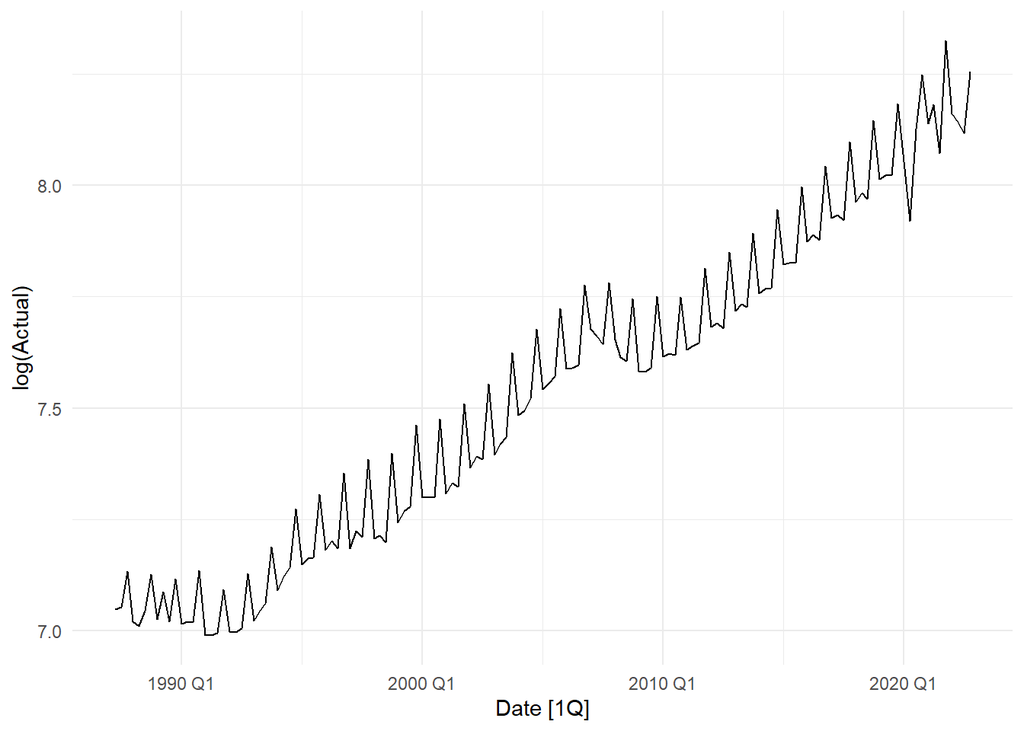

```r
# Linearity?
gdp %>%
  autoplot(log(Actual)) +
  theme_minimal()
```

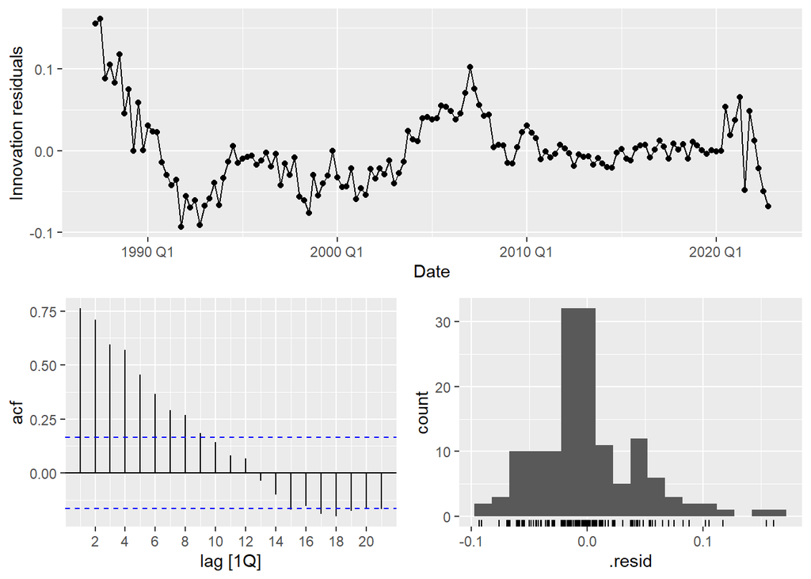

```r
# Independence, Normality, Equal Variance?
fit %>%
  gg_tsresiduals()
```

```r
# Perform Ljung-Box test
fit %>%
  augment() %>%
  features(.innov, features = ljung_box, lag = 16, dof = 9)
```

```
## # A tibble: 1 × 3
##   .model lb_stat lb_pvalue
##   <chr>    <dbl>     <dbl>
## 1 m3        355.         0
```

`Linearity` The plots suggest that there is a linear relationship between the log of actual GDP and time, but some nonlinear behavior is present. Therefore, we cannot confirm the satisfaction of the linearity assumption.

`Independence` The autocorrelation function (ACF) plot shows a significant positive autocorrelation, especially lag 1, indicating that there is some dependence between the current observation and past observations. The Ljung-Box test further proves this finding, as it displays a large statistic value of 355.3609 contributing to a very low P-value of 0. This indicates that we can reject the null hypothesis of white noise, and that there’s a relationship between the current time and the previous time.

`Normality` The distribution of the innovation residuals is not normally distributed, as evidenced by the asymmetric distribution caused by an observation located further to the right. Therefore, the right skew defies the normality distribution assumption.

`Equal Variance` The residuals plot suggests the presence of heteroscedasticity, as peaks and troughs are present over time. This pattern indicates that the variability of the residuals changes over time and violates the assumption of equal variance.